# Sample Solution for Circle Fitting

```python
import numpy as np
import matplotlib.pyplot as plt
%matplotlib inline

from scipy.optimize import least_squares
```

For each point on a circle, we know that $$(x-c_x)^2 + (y-c_y)^2 = r^2.$$ Using three points, we begin by shifting the coordinate system so that the first point is in the origin. The equation for this point is then simply $$c_x^2 + c_y^2 = r^2.$$ For the other two points, explicitly sqaring the parantheses and subsituting $r^2$, we find that the equations for the two remaining points simplify to $$2x_i c_x + 2y_i c_y = x_i^2 + y_i^2,$$ with $i \in \{2,3\}$, as the $c_x^2$-terms cancel out.

This is now simply a linear system of 2 equations in $c=(c_x, c_y)$. By putting the coefficients of both equations in matrix/vector form, we get a problem of the type $$ A c = b, $$ which can be easily solved.

```python
def cirle_from_points(points):

    # Moving the set of points to the orgin simplifies the problem
    offset = points[0]
    p = points - offset

    # 2x2 linear eq:
    A = 2 * p[1:, :]
    b = p[1:, 0]**2 + p[1:, 1]**2

    try:
        c = np.dot(np.linalg.inv(A), b)
        r = np.sqrt(c[0]**2 + c[1]**2)
    except np.linalg.linalg.LinAlgError:
        # If the points are on a straight line, there is no solution
        return np.NaN * np.zeros(2), np.NaN
    else:
        return c + offset, r
```

```python
data = np.load('circles.npy')

eps = 0.07              # Epsilon, the inlier tolerance
N_ransac = int(1e4)     # Number of RANSAC iterations
N_cicles = 6            # Number of cirlces to find

# Perform one ransac iteration:
def ransac_iter():
    # 1. Choose 3 points
    points = data[np.random.choice(all_indexes, 3, replace=False)]
    # 2. Calculate the circle through the points
    c, r = cirle_from_points(points)
    # 3. Check how far all other points are from the circle
    dist_from_circ = np.abs((data[:,0] - c[0])**2
                          + (data[:,1] - c[1])**2
                          - r**2)
    # 4. All below the epsilon theshhold are inliers
    inliers = dist_from_circ < eps**2

    return inliers, c, r


ransac_results = []
for n in range(N_cicles):

    all_indexes = np.arange(data.shape[0], dtype=int)   # Re-index the remaining data
    inliers_best = np.zeros(data.shape[0], dtype=bool)  # Inliers of the best solution
    score_best = 0                                      # Score of the best solution
    c_best, r_best = np.zeros(2), 0.                    # Parameters of the best solution

    for i in range(N_ransac):
        # From a single sample, fit the circle and count the inliers:
        inl, c, r = ransac_iter()
        score = np.sum(inl)
        # Update the current best:
        if score > score_best:
            score_best, inliers_best, c_best, r_best = score, inl, c, r

    ransac_results.append({'r':r_best, 'c':c_best, 'inliers':data[inliers_best]})
    # Remove all inliers before fitting the next circle
    data = data[np.logical_not(inliers_best)]
```

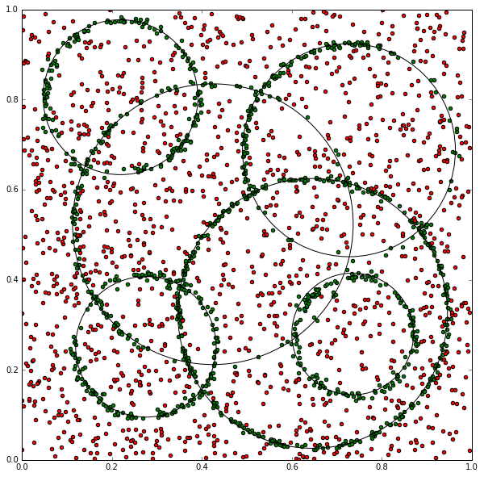

```python
# Function for showing the results
def show_cicles_and_data(results, outliers):
    plt.figure(figsize=(10,10))
    for r in results:
        plt.scatter(r['inliers'][:,0], r['inliers'][:,1], c='green')
        plt.gca().add_patch(plt.Circle(r['c'], radius=r['r'], fill=False))

    plt.scatter(outliers[:,0], outliers[:,1], c='red')
    plt.xlim(0,1)
    plt.ylim(0,1)


show_cicles_and_data(ransac_results, data)
```

In the image above, the green points represent the inliers red the outliers. Indeed, we see that the method worked as expected, finding all 6 circles. Each of the circles above was only computed using three points at a time. Therefore, we now continue by refining the circles using all inliers.

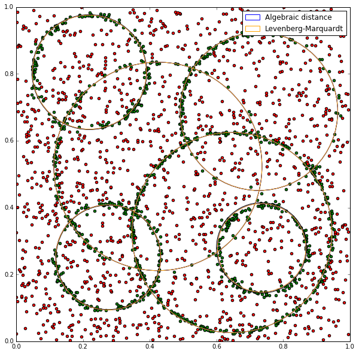

```python
def refine_fit(results, method):

    fit_results = []
    for circle in results:

        # Arguments must be a singe vector, therefore concatenate them
        def cost(cr):
            c, r = cr[:2], cr[2]
            if method == 'algebraic':
                return np.sum(np.linalg.norm(circle['inliers']-c, axis=1)**2 - r**2)
            elif method == 'lm':
                return np.sum(np.linalg.norm(circle['inliers']-c, axis=1) - r)

        # Use the RANSAC result as the best guess
        guess = np.concatenate((circle['c'], [circle['r']]))
        fit = least_squares(cost, guess)
        fit_results.append(fit.x)

    return fit_results

# Add circles to the diagram using a list of centers and radii
def show_refined_circles(results):

    circle_handles = []
    for method, color in [('algebraic', 'blue'), ('lm', 'orange')]:

        fit_results = refine_fit(results, method)
        for cr in fit_results:
            circle = plt.Circle(cr[:2], radius=cr[2], fill=False, edgecolor=color)
            plt.gca().add_patch(circle)
        # Remember the last circle for the legend
        circle_handles.append(circle)

    plt.legend(handles=circle_handles, labels=['Algebraic distance', 'Levenberg-Marquardt'])

show_cicles_and_data(ransac_results, data)
show_refined_circles(ransac_results)
```

In fact, we see that the fit using all inliers barely changes the determined circles. This is due to the narrow shape of the cirles lines and the low inlier thresshold we chose. To properly compare the two fitting methods, we have to artificially augment the data:

```
(0, 3)
```

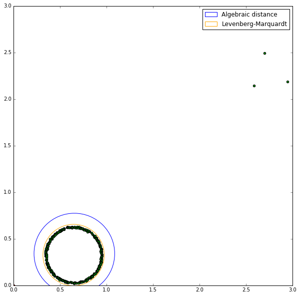

```python
# Using just one of the circles, add some fake outliers classified as inliers:
toy_results = ransac_results[0:1]
toy_results[0]['inliers'] = np.concatenate((toy_results[0]['inliers'],
                                            np.random.random((4,2))+(2.,2.)))

show_cicles_and_data(toy_results, np.zeros((1,2)))
show_refined_circles(toy_results)

plt.xlim(0,3)
plt.ylim(0,3)
```

Indeed, after adding artificial outliers, the LM fit stays much closer to the orgiginal circle than for the algebraic distance, because the latter weights outliers quadratically higher.